# Individual differences in circadian rhythms measured at a global scale

Author

Affiliation

Alex R Wade

University of York

Published

June 5, 2026

Abstract

Human cognition and physical performance vary across the day, and individuals differ systematically in *when* they peak — the morningness–eveningness dimension of chronotype research. We asked whether these rhythms appear in large-scale behavioural traces from ranked *League of Legends* matches. Using ~92.7 million games drawn from the top ~1,000 players on each of 8 regional servers, we built per-player hourly time series of in-game behaviour (two principal components of performance, PC1 and PC2) and of a skill-outcome measure (the change in matchmaking rating, ΔMMR). Play volume is governed by local time: correcting each server by its fixed UTC offset collapses the eight play-volume curves onto one evening-peaked schedule, cutting the across-server spread in mean play hour from 5.83 h to 1.12 h. Within-subject Lomb–Scargle periodograms revealed a sharp circadian peak: across servers the N-weighted best period was 23.96 h for PC1 and 23.94 h for PC2, and the population playtime periodogram peaked at exactly 24.0 h on every server. Per-player peak phases were individually significant for 14.2% of players on PC1 and 10.3% on PC2, and these peak times were broadly spread across the day (pooled circular standard deviation ≈ 7 h): players differ widely in when their behaviour peaks. The distribution is a single dispersed mode rather than two discrete clusters — a two-component von Mises mixture was not preferred over one component for either PC1 (ΔBIC = −15.7) or PC2 (ΔBIC = −15.4). One server (JP1) ran a daily maintenance shutdown that truncated its sampling window and produced a spurious morning cluster; we excluded it from the phase analyses. In contrast, ΔMMR carried almost no circadian signal (0.3% of players FDR-significant). Behaviour is strongly time-of-day structured, with wide individual differences in phase; competitive *success* is not. All analysis code and the de-identified derived outputs underlying every figure are openly available, and we discuss interpretation limits and the data-sharing constraints of proprietary match telemetry.

Keywords

circadian rhythms, chronotype, behavioural rhythms, open science, digital trace data, online games, League of Legends, Lomb–Scargle periodogram, computational social science

# 1 Introduction

Almost every measured aspect of human physiology and behaviour oscillates with a period of about 24 hours, driven by an endogenous circadian clock that is entrained to the local light–dark cycle [1]. These rhythms reach into cognition: attention, working memory, reaction time and executive control all show reliable time-of-day modulation [2]. But the *phase* of these rhythms differs between people. The morningness–eveningness dimension (colloquially “larks” versus “owls”) is a stable trait [3, 4], and the distribution of chronotypes in a population is broad and roughly continuous [5].

Chronotype matters for performance. When the timing of a demanding task is misaligned with a person’s internal clock (*social jet lag*), outcomes suffer. Using 3.4 million learning-management-system logins, [6] showed that the majority of students are chronically misaligned with their class schedules and that greater misalignment predicts lower grades. In elite sport, [7] found that an athlete’s peak performance time tracks their circadian phenotype, with intra-day swings as large as ~26%. In gamers with gaming disorder, eveningness has been linked to disrupted sleep and higher gaming-disorder risk [8], and competitive performance in esports is a structured, trainable skill set rather than mere reflex [9].

Online competitive gaming offers an unusually clean natural experiment for chronobiology at scale. Millions of timestamped, standardised, skill-graded matches are played around the clock, across the globe, by the same individuals over months. If circadian structure shapes human behaviour, it should be legible in this telemetry. *League of Legends* (LoL), a five-versus-five multiplayer game operated on geographically separated regional servers, is well suited to the question: each server has a known local time zone, allowing matches to be aligned to *local* hour, and matchmaking continuously updates each player’s skill estimate.

We test three questions:

1. **Existence.** Do individual players show ~24 h rhythms in their in-game behaviour?
2. **Individual variation.** If rhythms exist, how are personal peak times distributed across the population — do players differ in *when* they peak, and does that variation form discrete clusters or a continuous spread?
3. **Consequence.** Does the *outcome* of play (skill change, ΔMMR) carry the same circadian signature as behaviour, or is success time-invariant?

We address these with a within-subject spectral analysis of ~8,000 high-ranked players, replicated independently across 8 servers and combined by an N-weighted meta-analysis.

# 2 Methods

## 2.1 Data provenance and aggregation

The analysis reuses the large longitudinal *League of Legends* cohort provided by Riot Games and described by Aung et al. [10] and Vardal et al. [11]. Its defining feature is the sampling design: a random sample of players who registered **new accounts at the start of a competitive season** (accounts with no prior ranked history), followed across **one entire season** (21 January to November 2016) of default five-versus-five ranked Solo/Duo-queue play. Because every account enters ranked play at the same default matchmaking rating and is then observed continuously, the cohort offers an unusually clean within-subject view of each player’s full activity and skill trajectory, the property our within-player periodogram and ΔMMR analyses depend on. Each match row carries the per-minute performance fields we reduce by PCA together with the player’s pre-match rating, from which ΔMMR is derived. The same data lineage underpins prior work on this cohort: early-season learning rate predicts end-of-season skill [10], and the temporal *spacing* of practice (rather than its timing) shapes performance gains [11].

Riot Games supplied the raw match records as CSV files, which we loaded into a columnar store and queried through an embedded DuckDB analytical database [12], from which we materialised an hourly aggregate table. The specific on-disk format is incidental to the analysis. We analysed the **eight regional servers** used by the source-dataset papers [10, 11]: BR1, EUN1, EUW1, JP1, LA1, LA2, NA1 and OC1, together contributing ≈92.7 million ranked games; the remaining platforms (ID1, TR1 and the PBE1 public-beta realm) were excluded as small or unreliable. For each server we selected the `top_n_players = 1000` most active accounts and retained the first `max_hour_limit = 5000` hours (~208 days) of each player’s history to bound edge effects. Each match timestamp was converted to the server’s **local hour** using a fixed per-server UTC offset, so that “9 a.m.” means the same wall-clock experience on every server.

To check that this conversion does what it claims, we counted the analysed cohort’s games in each hour of the day, per server, in UTC and in local time (9.55 million games). We summarised each server’s schedule by the circular mean of its game-weighted play hour, measured the across-server circular standard deviation of those means before and after the offset, and regressed each server’s mean UTC play hour on its UTC offset. A common local schedule predicts a slope of −1 and a collapse in the across-server spread (Section 3.1).

## 2.2 Behavioural features and principal components

We derived seven rate features per game (gold, damage dealt, kills, deaths, assists, neutral creeps and enemy creeps, each per minute), plus the fraction of time spent dead. Population-level hourly features were standardised and reduced by sign-oriented principal component analysis (SVD); per-game player records were then projected onto this fixed basis so that every player is scored on a common set of axes. The first two components dominate:

- **PC1** (≈62% of variance) loads *positively* on all activity features, a general **in-game output / engagement intensity** axis (high PC1 = a busy, high-tempo game).
- **PC2** (≈19% of variance) contrasts farming/economy (creeps, gold) against time spent dead, an **economy-versus-attrition** axis.

A complementary “success-aware” PCA that included win rate was computed for descriptive comparison. As a direct skill-outcome metric we also computed **ΔMMR**, the within-player change in matchmaking rating from one game to the next.

## 2.3 Within-subject periodograms

For each player and each metric (PC1, PC2, ΔMMR) we placed the game-level scores on their irregular real-time stamps and computed a Lomb–Scargle periodogram [13, 14] over periods of 6–48 h (`player_n_freq = 2000` frequencies) using `astropy.timeseries.LombScargle` [15, 16]. The Lomb–Scargle estimator is appropriate here because match times are unevenly spaced. The (evenly spaced) frequency grid is **anchored so that exactly 24 h is a grid node**, allowing a true circadian peak to be reported at 24.0 h rather than snapping to a neighbouring bin. Per-player periodograms were then **incoherently averaged** within each server–metric cell (averaging *power*, which is phase-blind), and the period of maximum mean power was recorded as that cell’s best period. A population-level periodogram of raw activity (`TIMEPLAYED`) was computed analogously over 6–48 h.

## 2.4 Phase estimation and multiple-testing control

To locate *when* in the day each player peaks, we fitted a fixed 24 h sinusoid by ordinary least squares to each player’s series, converted the fitted lag to a **local peak hour** in $[0, 24)$, and tested the joint significance of the sinusoid. Across the players in each server–metric cell, the resulting $p$-values were corrected with the Benjamini–Hochberg false-discovery-rate procedure [17] at $\alpha = 0.05$. Only FDR-significant peak phases entered the modality analysis.

## 2.5 Circular modality: one mode versus two

Peak hours are circular. To ask whether personal peak times form a single spread or split into discrete clusters, for each server–metric cell with at least 20 FDR-significant phases we fitted two circular models to the phases (expressed as angles) [18–20]:

- a **one-component von Mises** distribution (mean direction $\mu$ and concentration $\kappa$ estimated from the resultant length); and
- a **two-component von Mises mixture** fitted by expectation–maximisation.

For each fit we report the fitted log likelihood and compare models by both the Akaike Information Criterion (AIC) [21] and Bayesian Information Criterion (BIC) [22], charging 2 free parameters to the one-component fit and 5 to the mixture: $\text{AIC} = 2k - 2\log L$ and $\text{BIC} = k\log n - 2\log L$. Positive $\Delta\text{AIC} = \text{AIC}_1 - \text{AIC}_2$ and $\Delta\text{BIC} = \text{BIC}_1 - \text{BIC}_2$ favour two components.

Because the usual chi-squared likelihood-ratio reference distribution is not valid for finite-mixture comparisons, we assessed the final pooled likelihood improvement with a parametric bootstrap. For each metric, we generated 1,000 datasets of the observed size from its fitted one-component model, refitted both models, and compared the simulated likelihood-ratio statistics with the observed statistic. We used the add-one correction $p = (r + 1)/(B + 1)$, where $r$ is the number of bootstrap statistics at least as large as observed and $B = 1{,}000$.

We report both a per-server tally and a final **pooled** fit that aggregates significant phases across servers (using only cells with ≥20 phases). As an assumption-light companion, we also summarised the same phases with phase-count-weighted circular kernel density estimates ($\kappa = 4$).

One server, **JP1**, was excluded from all phase-based analyses (per-player peak phase, its FDR fractions, the modality fits and the kernel density). JP1 runs a daily maintenance shutdown of roughly 05:00–11:00 local time (Figure 1), so the fixed 24 h sinusoid extrapolates each player’s peak into hours that were never sampled; JP1 also returns an implausible 72–76% FDR-significant fraction, against 10–28% elsewhere. Its phase estimates are therefore unreliable. JP1 is retained in the period analysis, where the frequency of a rhythm is recoverable from gapped sampling, and in the play-volume figure, where it documents the gap. The phase analyses thus rest on 7 servers.

## 2.6 Across-server meta-analysis and quality control

All headline numbers are **N-weighted across servers**: period peaks are weighted by the number of valid players, phase fractions by players analysed, and population metrics by games played. Implementation used NumPy [23], SciPy [24], pandas [25] and Matplotlib [26].

## 2.7 Computational reproducibility

The full workflow is script-based and deterministic at the level of published summary tables and figures. Server-level processing is run with `riot_analysis.py`, and cross-server synthesis and manuscript figures are run with `grand_analysis.py`. Intermediate and final outputs are written to the `results/` tree, and manuscript figures are generated from those tables rather than from manual plotting steps. The repository includes the Quarto source for the manuscript and rebuild commands so that text, statistics and figures can be regenerated from the released derived data products.

**NoteOutlier handling**

Two server-level period estimates (both from **JP1**) were clear outliers and were excluded from the period meta-analysis: its ΔMMR peak (44.4 h, an implausible near-double of the circadian period) and its PC1 peak (8.0 h, a flip onto the third harmonic of the daily cycle). Outliers were flagged *within* each metric by a median/MAD modified $z$-score (|z| > 3.5) combined with an absolute-deviation gate (> 3 h from the median); the gate keeps genuine near-circadian values (peaks one or two grid bins either side of 24 h) while still catching harmonics and long-period artifacts, and it also decides the case where the 24 h-anchored grid collapses the MAD to zero by placing most servers on the same bin. After exclusion PC1 and ΔMMR rest on 7 servers / 7,000 players each; PC2 retains all 8.

# 3 Results

## 3.1 Play volume is set by local time, not UTC

The clearest daily signal in the data is how much people play, and local time governs it. Each server spreads its games unevenly across the day, with a deep trough in the small hours and a broad evening peak carrying 6–10% of that server’s games in each hour (Figure 1). Plotted against UTC, the eight curves are displaced from one another in time-zone order, from OC1 (UTC+10) on the left to LA1 (UTC−6) on the right. Applying the fixed per-server UTC offset collapses them onto one evening-peaked schedule: the across-server circular standard deviation of the mean play hour falls from **5.83 h in UTC to 1.12 h in local time**, and the pooled local mean play hour is 19.1 h.

The displacement is the time zone and nothing else. Regressing each server’s mean UTC play hour on its UTC offset gives a slope of **−0.92** (r = −0.98), against the −1 predicted if every server keeps the same local schedule. Two features of the exposure schedule are operational rather than behavioural: JP1 records almost no play between 05:00 and 11:00 local, and LA1 and LA2 each lose a single hour, at 03:00–04:00 and 06:00–07:00 local respectively, which are the *same* hour (09:00–10:00) in UTC. Fixed-UTC gaps are daily server maintenance, not sleep. JP1’s seven-hour gap is what pulls the slope away from −1; excluding JP1 the slope is **−0.99** (r = −0.98) and the local-time standard deviation falls to 0.94 h.

Local hour is therefore the meaningful axis for everything that follows, and the rhythms reported below cannot be inherited from pooling servers in the wrong time frame. The residual across-server spread of 1.12 h bounds how much of any phase structure a time-zone error could manufacture, far smaller than the ~7 h spread of individual peak phases reported in Section 3.4. This figure also exposes the maintenance-window gaps (chiefly JP1’s) that motivate the phase-analysis exclusions below.

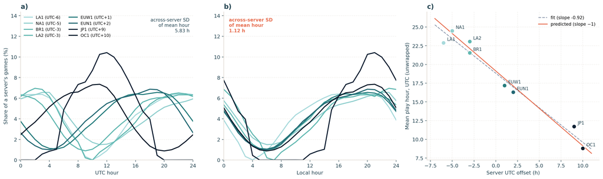

Figure 1: Play volume by hour of day on the eight servers (9.55 million games from the 8,000 analysed players). **(a)** Share of each server’s games falling in each UTC hour; servers are coloured by UTC offset (light = west, dark = east) and the curves are displaced in time-zone order. **(b)** The same curves against local hour, after the fixed per-server UTC offset, collapsing onto a common evening-peaked schedule. **(c)** Each server’s mean UTC play hour against its UTC offset; the fitted slope (−0.92) sits close to the −1 expected if all servers keep the same local schedule (solid line, drawn through the pooled local mean of 19.1 h). JP1’s flat interval at 05:00–11:00 local, and the single missing hour on LA1 and LA2 (both 09:00–10:00 UTC), are daily server-maintenance windows rather than behaviour.

## 3.2 Behaviour is rhythmic; success is not

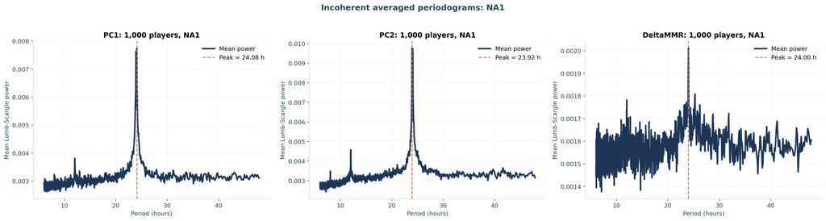

This pattern is consistent across all servers. The N-weighted best period is **23.96 h for PC1** (SEM 0.029) and **23.94 h for PC2** (SEM 0.020), both indistinguishable from 24 h, with small between-server scatter; the ΔMMR peak averages **exactly 24.00 h** (after removing the JP1 outlier) but rests on a far weaker peak (Table 1).

Table 1: N-weighted within-subject best periods.

| Metric | Servers | Players | Best period (h) | SEM (h) |
| --- | --- | --- | --- | --- |
| PC1 | 7 | 7,000 | 23.96 | 0.029 |
| PC2 | 8 | 8,000 | 23.94 | 0.020 |
| ΔMMR | 7 | 7,000 | 24.00 | 0.015 |

The fraction of *individually* FDR-significant players tells the same story (excluding JP1; see Section 3.4): **14.2%** of players have a significant ~24 h rhythm in PC1 and **10.3%** in PC2, but only **0.3%** do in ΔMMR (24 of 7,000 players). Behaviour is strongly clock-locked; the *outcome* of competition is clock-agnostic.

For reference, the population-level periodogram of raw activity (`TIMEPLAYED`) behaves as expected: with the 24 h-anchored grid it peaks at **exactly 24.0 h on every one of the eight servers**.

## 3.3 What the components mean

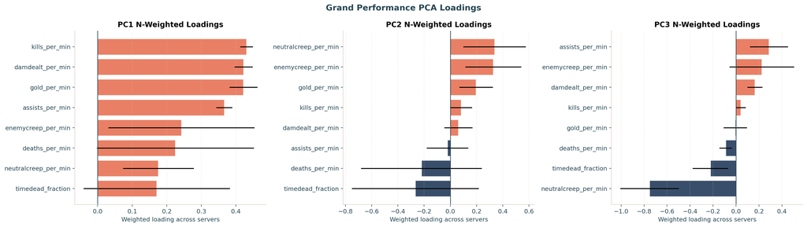

(a) Performance PCA: PC1 is an all-positive output/engagement axis (~62% variance); PC2 contrasts economy against time-dead (~19%).

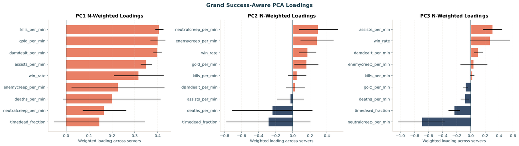

(b) Success-aware PCA (win rate included): win rate loads only modestly on the leading components.

Figure 3: N-weighted PCA loadings across servers; whiskers show between-server spread.

## 3.4 Peak times vary widely across the population

The central question is the *shape* of the peak-time distribution. Pooling the FDR-significant phases across the seven retained servers, personal peak times are **broadly spread across the day** rather than clustered: the single-component von Mises fit has low concentration ($\kappa \approx 0.4$, circular standard deviation ≈ 7 h), loosely centred on the late evening for PC1 (mean 23.7 h) and around midday for PC2 (12.4 h). Players differ widely in when their behaviour peaks.

That spread is a **single dispersed mode, not two discrete clusters**. Comparing circular models, a two-component von Mises mixture was **not** preferred over one component for either metric (Figure 4, Table 2):

- **PC1** (992 phases): adding a second component barely changed the log likelihood (−1,784.9 to −1,782.4; likelihood ratio 5.0). BIC penalised the extra parameters ($\Delta\text{BIC} = -15.7$; $\Delta\text{AIC} = -1.0$), and the improvement was not significant against a one-component null (62 of 1,000 bootstrap replicates matched or exceeded it, $p = .063$).
- **PC2** (704 phases): likewise a negligible gain (−1,263.2 to −1,261.1; likelihood ratio 4.3; $\Delta\text{BIC} = -15.4$; $\Delta\text{AIC} = -1.7$; $p = .128$).

ΔMMR could not be tested for modality at all: no server reached the 20-significant-phase threshold, so the pooled ΔMMR cell is empty.

Table 2: Pooled one- versus two-component circular fit on FDR-significant peak phases (JP1 excluded). For both metrics BIC prefers the single component and the bootstrap likelihood-ratio test is non-significant: no evidence for two discrete clusters.

| Metric | Phases | log L 1 | log L 2 | AIC 1 | AIC 2 | BIC 1 | BIC 2 | Bootstrap $p$ |
| --- | --- | --- | --- | --- | --- | --- | --- | --- |
| PC1 | 992 | −1,784.9 | −1,782.4 | 3,573.8 | 3,574.7 | 3,583.6 | 3,599.2 | .063 |
| PC2 | 704 | −1,263.2 | −1,261.1 | 2,530.4 | 2,532.1 | 2,539.5 | 2,554.9 | .128 |
| ΔMMR | 0 | n/a | n/a | n/a | n/a | n/a | n/a | n/a |

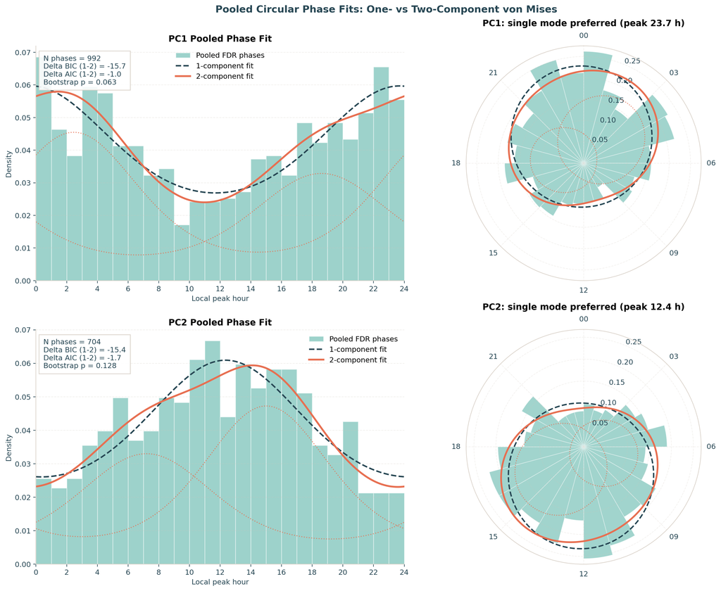

Figure 4: Pooled circular phase fits. For PC1 (top) and PC2 (bottom): histograms of FDR-significant local peak hours with the one-component fit (dashed) and two-component fit (solid; dotted components), in hour-domain (left) and polar (right) views. The single von Mises tracks the data as well as the mixture; both metrics show one broad, dispersed mode rather than two clusters, and BIC and a bootstrap likelihood-ratio test do not support a second component. JP1 is excluded (see text).

The per-server tally agrees: across the retained servers, FDR-significant PC1 phases split 816 (one-component-preferred) to 176 (two-component-preferred) and PC2 704 to 0. Almost every server-level cell independently favours a single mode.

An assumption-light kernel-density view (Figure 5) reproduces the same landscape: the phase-count-weighted circular density of PC1 peaks is a single broad concentration in the late evening (weighted peak 23.7 h) and PC2 a single broad concentration around midday (12.5 h), each spread across most of the clock.

**The apparent two-cluster structure was a JP1 artifact.** With JP1’s phases included, the pooled fits instead prefer two components ($\Delta\text{BIC} = +17$ for PC1, $+28$ for PC2) with a morning “lark” mode near 7–9 h. That morning mode sits inside JP1’s daily 05:00–11:00 maintenance shutdown (Figure 1), where no games are played: the 24 h sinusoid extrapolates each JP1 player’s peak into hours that were never sampled. JP1 alone supplies 72–76% of its players as FDR-significant and 42–52% of the pooled phases, so it dominates the pooled fit. Removing JP1 (Methods) removes the spurious clusters and leaves the single broad distribution above.

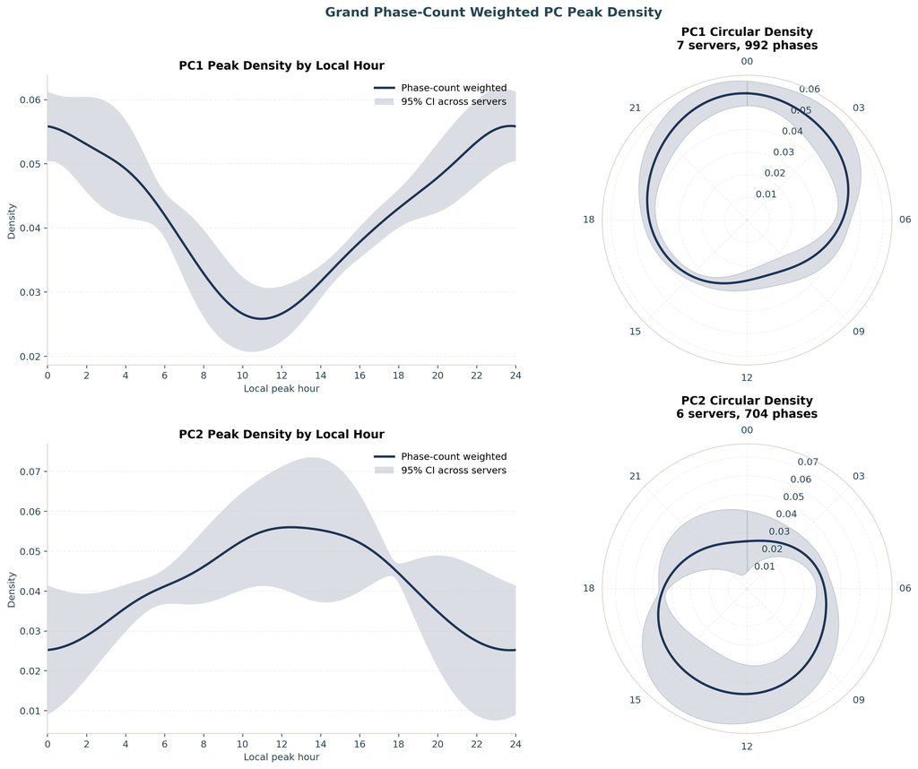

Figure 5: Phase-count-weighted circular kernel density of FDR-significant peak hours (κ = 4), with 95% across-server bands (JP1 excluded). Each metric shows a single broad concentration — PC1 in the late evening, PC2 around midday — spread across most of the day.

# 4 Discussion

Three findings stand out. First, **circadian rhythms are real and strong in LoL play behaviour**: within-subject periodograms peak crisply at 24 h for both behavioural principal components, the estimate is stable to three significant figures across independent servers, and roughly one in seven players carries an individually significant daily rhythm. This large naturalistic analysis complements educational [6] and athletic [7] big-data work.

Second, **personal peak times vary widely across the population, as a broad continuous spread rather than two discrete clusters**. The FDR-significant peak phases scatter across most of the day (circular standard deviation ≈ 7 h), and a single von Mises describes them as well as a two-component mixture (BIC and a parametric-bootstrap likelihood-ratio test do not support a second component). This wide individual variation is consistent with the broad, roughly *continuous* distribution of chronotypes reported in the survey literature [4, 5], rather than with a clean split into larks and owls. We are careful about the label: what we measure is a *behavioural* phase — the hour at which a player’s in-game output peaks — which is not the physiological dim-light melatonin onset, and is shaped by chronotype together with school, work and social schedules.

An apparent bimodality in an earlier pass of this analysis turned out to be a sampling artifact. A single server, JP1, contributed 42–52% of the pooled significant phases and, on its own, produced a morning “lark” cluster; excluding it removed the second mode entirely. JP1 runs a daily maintenance shutdown (~05:00–11:00 local) during which no games are recorded (Figure 1), so the fitted 24 h sinusoid extrapolates each player’s peak into hours that were never sampled, manufacturing a morning cluster exactly where the data are missing. The lesson generalises: in always-on behavioural telemetry, platform downtime imposes structured, fixed-clock gaps that can masquerade as biology, and phase estimates are especially vulnerable because a peak can be placed in an unsampled window. We flag and exclude JP1 from the phase analyses for this reason.

Third, **competitive success is essentially time-invariant**. ΔMMR shows no within-subject circadian rhythm (0.3% FDR-significant; no server testable for modality), even though the very same players, on the very same games, show clear rhythms in *how* they play. The matchmaking system is designed to hold win rate near 50% by pairing players of similar skill, which mechanically suppresses any outcome rhythm; and because both teams in a match share the same server clock, a pure time-of-day effect cancels within every game and cannot move the result. The two timescales behave differently: on this very cohort, *across*-season skill change is highly structured and predictable (early-season learning rate forecasts end-of-season rating [10]), yet the *within*-day timing of skill change leaves no detectable circadian mark. Prior analyses of this same dataset deliberately set MMR aside as a match-to-match performance measure, precisely because it is governed by the (opaque, win/loss-weighted) matchmaking algorithm rather than by momentary individual play [11]; our null is the chronobiological counterpart of that caution. For a competitive player the practical implication is twofold: playing *style* varies with the time of day, but the matchmaking ladder largely cancels its effect on measured skill.

## 4.1 Limitations

This is an observational analysis of a self-selected, highly active, high-ranked population (top ~1,000 per server), so the distribution of phases we recover need not match the general public. Phases are inferred from a fitted 24 h sinusoid on irregular match times rather than from continuous physiological recording. Local hour uses a single per-server UTC offset and does not model daylight-saving transitions or the within-region spread of true time zones; the residual across-server spread this leaves is 1.12 h (Section 3.1). Daily maintenance windows remove a few hours of exposure from JP1, LA1 and LA2 (Figure 1), which censors those hours rather than sampling them; because this most strongly corrupts phase estimation, we excluded JP1 (the largest gap) from the phase analyses, and the phase results should be read as conditional on that choice. The one- versus two-component von Mises comparison is the simplest test of clustering and does not exclude richer multi-modal or continuous structure; a single broad mode is the most it supports here. The parametric bootstrap tests how often an improvement this large arises from a fitted one-component von Mises model, conditional on the retained pooled phases; it does not repeat the upstream phase estimation and FDR-selection pipeline or model dependence within servers. Finally, the headline meta-analysis weights servers by N; alternative weightings (e.g. equal-server) give qualitatively the same conclusions but slightly different point estimates.

## 4.2 Conclusion

Across 8 global servers and ~8,000 players, *League of Legends* behaviour is circadian and personal peak times vary widely across the population — a broad, continuous spread of individual phases rather than two discrete chronotypes — while competitive outcome carries no daily rhythm at all. Match telemetry from a popular game provides a quantitative window into human chronobiology, and the analysis pipeline here (within-subject Lomb–Scargle, FDR-controlled phase estimation, information-criterion-compared circular models, and parametric-bootstrap model checking, meta-analysed across servers) is a reusable template for similar questions in other large behavioural datasets — provided, as JP1 shows, that structured gaps from platform downtime are screened before phases are pooled.

# Declarations

## 4.3 Ethics approval and consent to participate

Not applicable. This study used secondary analysis of de-identified gameplay telemetry supplied under prior data-sharing agreements and did not involve direct interaction with human participants.

## 4.4 Consent for publication

Not applicable.

## 4.5 Data accessibility

The analysis code (`riot_analysis.py`, `grand_analysis.py`) and the de-identified derived outputs that underlie every figure and statistic in this paper (the per-server and grand summary tables under `results/`) are openly available at https://github.com/wadelab/MSc2026_LoL_Release. The shared outputs carry no player account identifiers or raw matchmaking ratings: the per-account selection lists are withheld, and only de-identified aggregates are released. The raw match records are proprietary to Riot Games and restrictions apply to their availability: they were used for the current study under the terms governing the longitudinal research cohort of Aung et al. [10] and Vardal et al. [11], and so are not publicly available. We do not redistribute them, and the pipeline rebuilds a local DuckDB cache from the converted store on demand.

## 4.6 Reproducibility and code availability

The repository contains script-level analysis entry points, generated result tables, and manuscript source. A full manuscript rebuild (HTML/PDF/DOCX) is run with `quarto render paper/journal_variants/lol_circadian_rhythms_rsos.qmd`. Core analysis artifacts in `results/` map directly onto reported statistics, tables and figure panels.

## 4.7 Competing interests

The author declares that they have no competing interests.

## 4.8 Funding

No specific funding was received for this work.

## 4.9 Abbreviations

LoL: *League of Legends*; MMR: matchmaking rating; FDR: false discovery rate; AIC: Akaike Information Criterion; BIC: Bayesian Information Criterion.

## 4.10 Authors’ contributions

A.R.W. designed the study, performed the analysis, and wrote the manuscript. The author read and approved the final manuscript.

## 4.11 Acknowledgements

The author thanks Riot Games for the generous donation of the match data that made this study possible.

# References

1.

Roenneberg T, Kuehnle T, Juda M, et al (2007) Epidemiology of the human circadian clock. Sleep Medicine Reviews 11:429–438. https://doi.org/10.1016/j.smrv.2007.07.005

2.

Schmidt C, Collette F, Cajochen C, Peigneux P (2007) A time to think: Circadian rhythms in human cognition. Cognitive Neuropsychology 24:755–789. https://doi.org/10.1080/02643290701754158

3.

Horne JA, Östberg O (1976) A self-assessment questionnaire to determine morningness-eveningness in human circadian rhythms. International Journal of Chronobiology 4:97–110

4.

Roenneberg T, Wirz-Justice A, Merrow M (2003) Life between clocks: Daily temporal patterns of human chronotypes. Journal of Biological Rhythms 18:80–90. https://doi.org/10.1177/0748730402239679

5.

Adan A, Archer SN, Hidalgo MP, et al (2012) Circadian typology: A comprehensive review. Chronobiology International 29:1153–1175. https://doi.org/10.3109/07420528.2012.719971

6.

Smarr BL, Schirmer AE (2018) 3.4 million real-world learning management system logins reveal the majority of students experience social jet lag correlated with decreased performance. Scientific Reports 8:4793. https://doi.org/10.1038/s41598-018-23044-8

7.

Facer-Childs E, Brandstaetter R (2015) The impact of circadian phenotype and time since awakening on diurnal performance in athletes. Current Biology 25:518–522. https://doi.org/10.1016/j.cub.2014.12.036

8.

Hsu T-W, Yen J-Y, Yeh W-C, Ko C-H (2024) Circadian typology and physical activity in young adults with gaming disorder. Medicina 60:1950. https://doi.org/10.3390/medicina60121950

9.

Nagorsky E, Wiemeyer J (2020) The structure of performance and training in esports. PLOS ONE 15:e0237584. https://doi.org/10.1371/journal.pone.0237584

10.

Aung MT, Bonometti V, Drachen A, et al (2018) [Predicting skill learning in a large, longitudinal MOBA dataset](https://doi.org/10.1109/CIG.2018.8490431). In: 2018 IEEE conference on computational intelligence and games (CIG). IEEE

11.

Vardal O, Bonometti V, Drachen A, et al (2022) Mind the gap: Distributed practice enhances performance in a MOBA game. PLOS ONE 17:e0275843. https://doi.org/10.1371/journal.pone.0275843

12.

Raasveldt M, Mühleisen H (2019) [DuckDB: An embeddable analytical database](https://doi.org/10.1145/3299869.3320212). In: Proceedings of the 2019 international conference on management of data (SIGMOD). pp 1981–1984

13.

Lomb NR (1976) Least-squares frequency analysis of unequally spaced data. Astrophysics and Space Science 39:447–462. https://doi.org/10.1007/BF00648343

14.

Scargle JD (1982) Studies in astronomical time series analysis. II. Statistical aspects of spectral analysis of unevenly spaced data. The Astrophysical Journal 263:835–853. https://doi.org/10.1086/160554

15.

Astropy Collaboration (2018) The Astropy project: Building an open-science project and status of the v2.0 core package. The Astronomical Journal 156:123. https://doi.org/10.3847/1538-3881/aabc4f

16.

VanderPlas JT (2018) Understanding the lomb-scargle periodogram. The Astrophysical Journal Supplement Series 236:16. https://doi.org/10.3847/1538-4365/aab766

17.

Benjamini Y, Hochberg Y (1995) Controlling the false discovery rate: A practical and powerful approach to multiple testing. Journal of the Royal Statistical Society: Series B (Methodological) 57:289–300. https://doi.org/10.1111/j.2517-6161.1995.tb02031.x

18.

Fisher NI (1993) [Statistical analysis of circular data](https://doi.org/10.1017/CBO9780511564345). Cambridge University Press, Cambridge

19.

Mardia KV, Jupp PE (2000) [Directional statistics](https://doi.org/10.1002/9780470316979). John Wiley & Sons, Chichester

20.

Berens P (2009) CircStat: A MATLAB toolbox for circular statistics. Journal of Statistical Software 31:1–21. https://doi.org/10.18637/jss.v031.i10

21.

Akaike H (1974) A new look at the statistical model identification. IEEE Transactions on Automatic Control 19:716–723. https://doi.org/10.1109/TAC.1974.1100705

22.

Schwarz G (1978) Estimating the dimension of a model. The Annals of Statistics 6:461–464. https://doi.org/10.1214/aos/1176344136

23.

Harris CR, Millman KJ, Walt SJ van der, et al (2020) Array programming with NumPy. Nature 585:357–362. https://doi.org/10.1038/s41586-020-2649-2

24.

Virtanen P, Gommers R, Oliphant TE, et al (2020) SciPy 1.0: Fundamental algorithms for scientific computing in Python. Nature Methods 17:261–272. https://doi.org/10.1038/s41592-019-0686-2

25.

McKinney W (2010) [Data structures for statistical computing in Python](https://doi.org/10.25080/Majora-92bf1922-00a). In: Proceedings of the 9th python in science conference. pp 56–61

26.

Hunter JD (2007) Matplotlib: A 2D graphics environment. Computing in Science & Engineering 9:90–95. https://doi.org/10.1109/MCSE.2007.55